# Canary Rockfish BC: a DFO Case Study Operating model

Technical report for Fisheries and Oceans Canada

Tom Carruthers, University of British Columbia t.carruthers@oceans.ubc.ca

November 2017

# Introduction

This operating model was specified using a stock assessment document:

Stanley, R.D., Starr, P., Olsen, N. 2009. Stock assessment for Canary rockfish (Sebastes pinninger) in British Columbia waters. Canadian Science Advisory Secretariat. Research Document.

## Robustness tests

Two critical sources of uncertainty are the discard mortality rate and the level of dead discarding.

1. The slot DR controls the general level of discarding. There may be significant general discarding that may or may not be important depending on the discard mortality rate Fdisc
2. The default range is assumed to be 80-100 percent. This could be influencial with management measures such as size limits.

# Operating Model

The OM rdata file can be downloaded from here

Download and import into R using `myOM <- readRDS('OM.rdata')`

## Species Information

**Species**: *Sebastes pinniger*

**Common Name**: *Canary Rockfish*

**Management Agency**: DFO

**Region**: British Columbia

**Latitude**: 54.5, 53, 51.2, 48.2, 48.2, 50, 54.5

**Longitude**: -134, -133.5, -131, -125.8, -122, -122, 129

## OM Parameters

**OM Name**: Name of the operating model: Canary_Rockfish_BC_DFO

**proyears**: The number of projected years: 50

**interval**: The assessment interval - how often would you like to update the management system? 4

**pstar**: The percentile of the sample of the management recommendation for each method: 0.5

**maxF**: Maximum instantaneous fishing mortality rate that may be simulated for any given age class: 0.8

**reps**: Number of samples of the management recommendation for each method. Note that when this is set to 1, the mean value of the data inputs is used. 1

**Source**: A reference to a website or article from which parameters were taken to define the operating model

Stock assessment for Canary rockfish (Sebastes pinniger) in British Columbia waters. Stanley R. Starr P. Olsen N.

# Custom Parameters

Stock depletion and natural mortality rate are both assigned custom parameters that are log-normmal random variables with means from the assessment document and CVs of 20 and 15 per cent, respectively.

# Stock Parameters

### Mortality and age: maxage, R0, M, Msd

**maxage**: The maximum age of individuals that is simulated. There are maxage+1 (recruitment to age-0) age classes in the storage matrices. maxage is the plus group where all age-classes > maxage are grouped, unless option switched off with OM@cpars$plusgroup=0 . Single value. Positive integer.

Specified Value(s): 116

Here we assume a maximum age of 116 which roughly corresponds with the age at which survival is 1% given the lowest bound on natural mortality rate of 0.04, ie. –ln(0.01)/0.04 = 115.13.

**R0**: Initial number of unfished recruits to age-0. This number is used to scale the size of the population to match catch or data, but does not affect any of the population dynamics unless the OM has been conditioned with data. As a result, for a data-limited fishery any number can be used for R0 . In data-rich stocks R0 may be estimated as part of a stock assessment, but for data limited stocks users can choose either an arbitrary number (say, 1000) or choose a number that produces simulated catches in recent historical years that are similar to real world catch data. Single value. Positive real number.

Specified Value(s): 1000

Unless management options are specified in absolute numbers (e.g. tonnes) the MSE is scale-less (has no units) and this value is inconsequential. Here it is set to 1000 arbitrarily.

**M**: The instantaneous rate of natural mortality. For each simulation a single value is drawn from a uniform distribution specified by the upper and lower bounds provided. Uniform distribution lower and upper bounds. Non-negative real numbers.

Specified in cpars: 0.04, 0.09

the assessment assumes a point value of M of 0.06 y-1 (page 12) for both male fish and females aged 0-13. This was bracketed by +/- 30% leading to a mean M in the range of 0.04 – 0.09 to represent uncertainty commensurate with the brief assessment review of M values that have been applied previously ranging from 0.02 in young males to 0.12 for older female fish

**Msd**: Inter-annual variation in M expressed as a coefficient of variation of a log-normal distribution. For each simulation a single value is drawn from a uniform distribution specified by the upper and lower bounds provided. If this parameter is positive, yearly M is drawn from a log-normal distribution with a mean specified by log(M) drawn for that simulation and a standard deviation in log space specified by the value of Msd drawn for that simulation. Uniform distribution lower and upper bounds. Non-negative real numbers

Specified Value(s): 0.05, 0.2

Given that M is very poorly quantified in most fishery settings, the annual variability in M is poorly known but likely to vary due to variability in predation pressure, food availability, disease and the density of the stock and related stocks that compete for prey or cannibalize recruits. To address the possibility of M changing among years in these simulations I set an arbitrary level of inter-annual variability with a lognormal CV of between 5% and 20% (i.e. 0.05 – 0.2), corresponding with 95% probability interval of +/-10% to +/- 40%. Note that due to the longevity of Canary Rockfish quite substantial inter-annual variability in M would be necessary to generate data inconsistent with the assumption of time-invariant M (noting the possible exception of a trend in M, below).

### Natural Mortality Parameters

#### Sampled Parameters

Histograms of simulations of `M`, and `Msd` parameters, with vertical colored lines indicating 3 randomly drawn values used in other plots:

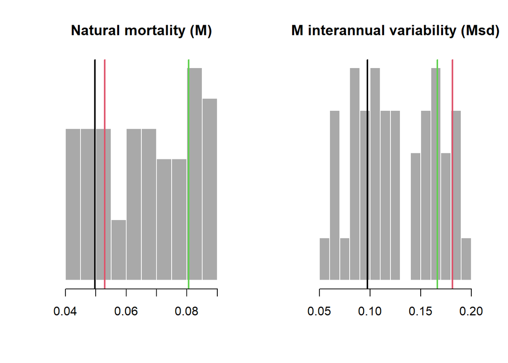

#### Time-Series

The average natural mortality rate by year for adult fish for 3 simulations. The vertical dashed line indicates the end of the historical period:

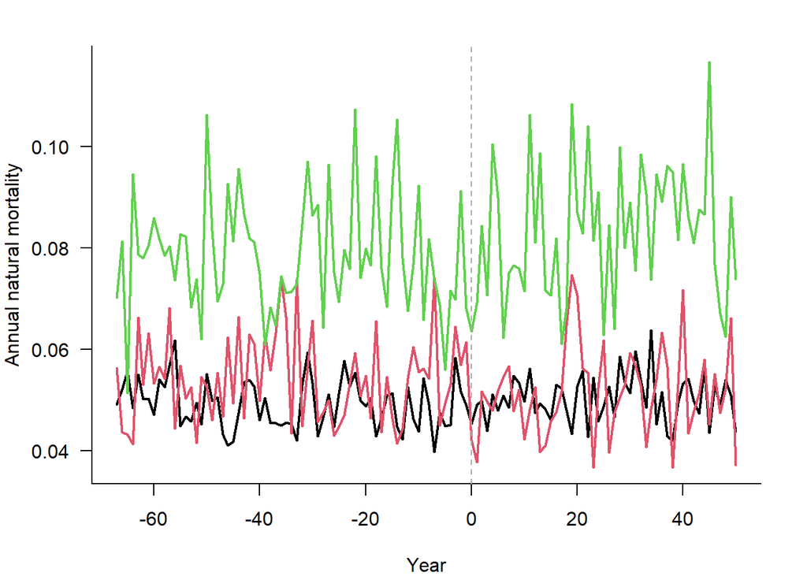

#### M-at-Age

Natural mortality-at-age for 3 simulations in the first historical year, the last historical year (i.e., current year), and the last projected year:

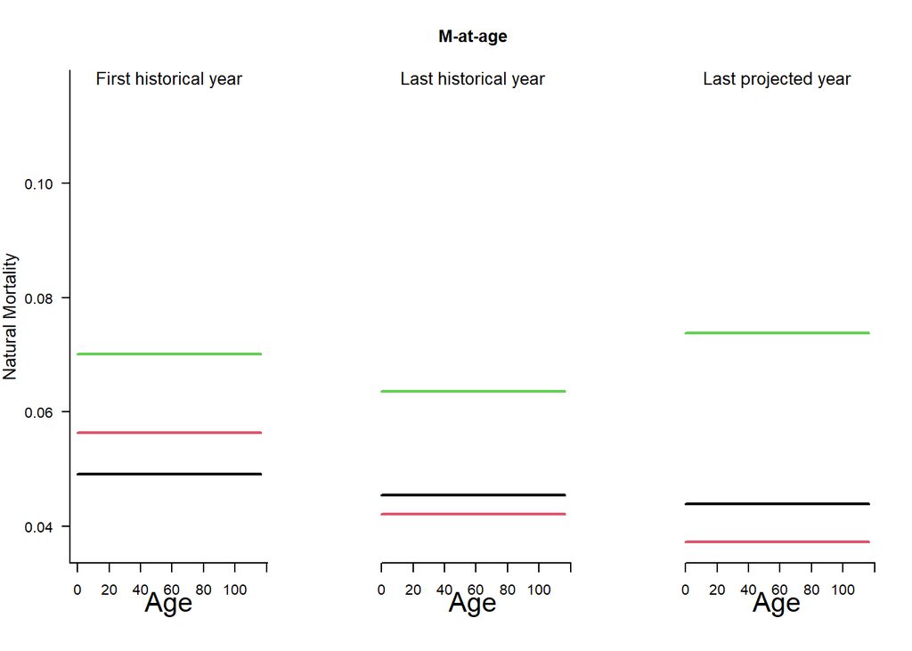

#### M-at-Length

Natural mortality-at-length for 3 simulations in the first historical year, the last historical year (i.e., current year), and the last projected year:

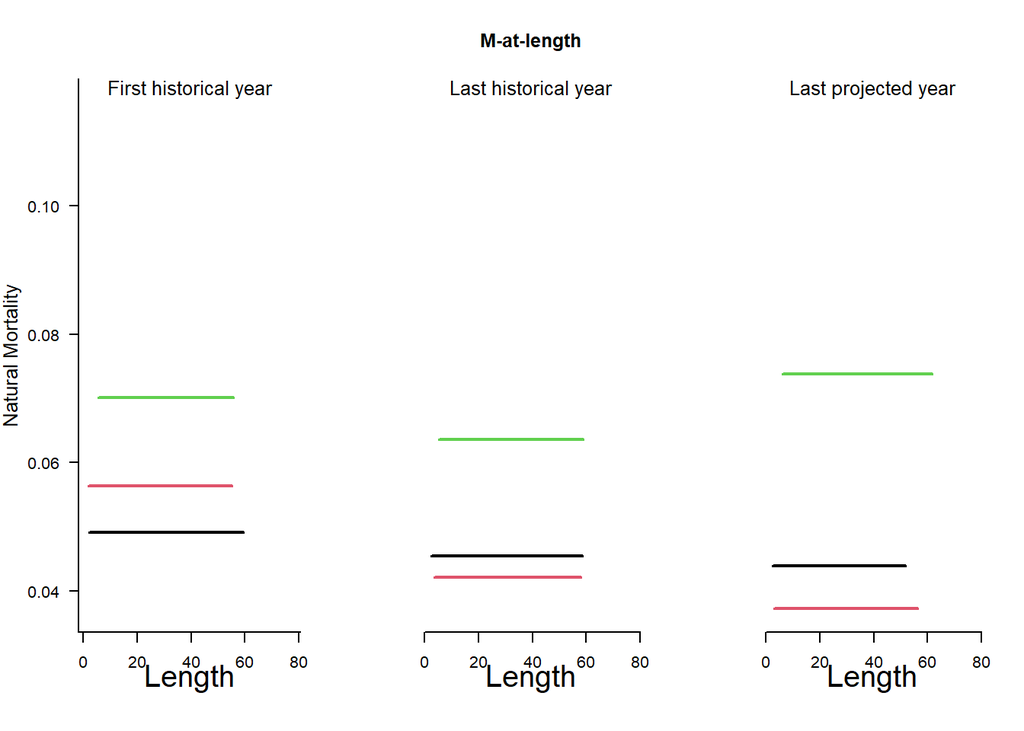

### Recruitment: h, SRrel, Perr, AC

**h**: Steepness of the stock recruit relationship. Steepness governs the proportion of unfished recruits produced when the stock is at 20% of the unfished population size. For each simulation a single value is drawn from a uniform distribution specified by the upper and lower bounds provided. This value is the same in all years of a given simulation. Uniform distribution lower and upper bounds. Values from 1/5 to 1.

Specified Value(s): 0.55, 0.7

The assessment specifies two possible values for steepness (Table J.6., page 156) that are used here to specify a reasonably wide range.

**SRrel**: Type of stock-recruit relationship. Use 1 to select a Beverton Holt relationship, 2 to select a Ricker relationship. Single value. Integer

Specified Value(s): 1

A value of 1 represents the Beverton-Holt stock recruitment curve which is commonly assumed form of density dependence for rockfishes in BC.

**Perr**: Recruitment process error, which is defined as the standard deviation of the recruitment deviations in log space. For each simulation a single value is drawn from a uniform distribution specified by the upper and lower bounds provided. Uniform distribution lower and upper bounds. Non-negative real numbers.

Specified Value(s): 0.25, 0.32

Figures J.5, J.9, J.13 (pages 172, 175, 178 of the assessment, respectively) show inter-annual variability expressed as a log-normal CV in the range of 0.25 –0.32 (see Figure 1 below)

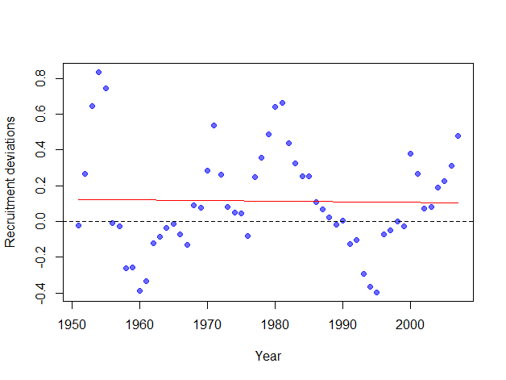

Figure J.13 from assessment document

**AC**: Autocorrelation in the recruitment deviations in log space. For each simulation a single value is drawn from a uniform distribution specified by the upper and lower bounds provided, and used to add lag-1 auto-correlation to the log recruitment deviations. Uniform distribution lower and upper bounds. Non-negative real numbers.

Specified Value(s): 0.75, 0.81

The lag 1 autocorrelation in recruitment. Figures J.5, J.9, J.13 (pages 172, 175, 178 of the assessment, respectively) show recruitment autocorrelation of between 0.75-0.81 (see Figure 1 below)

### Recruitment Parameters

#### Sampled Parameters

Histograms of 48 simulations of steepness (`h`), recruitment process error (`Perr`) and auto-correlation (`AC`) for the Beverton-Holt stock-recruitment relationship, with vertical colored lines indicating 3 randomly drawn values used in other plots:

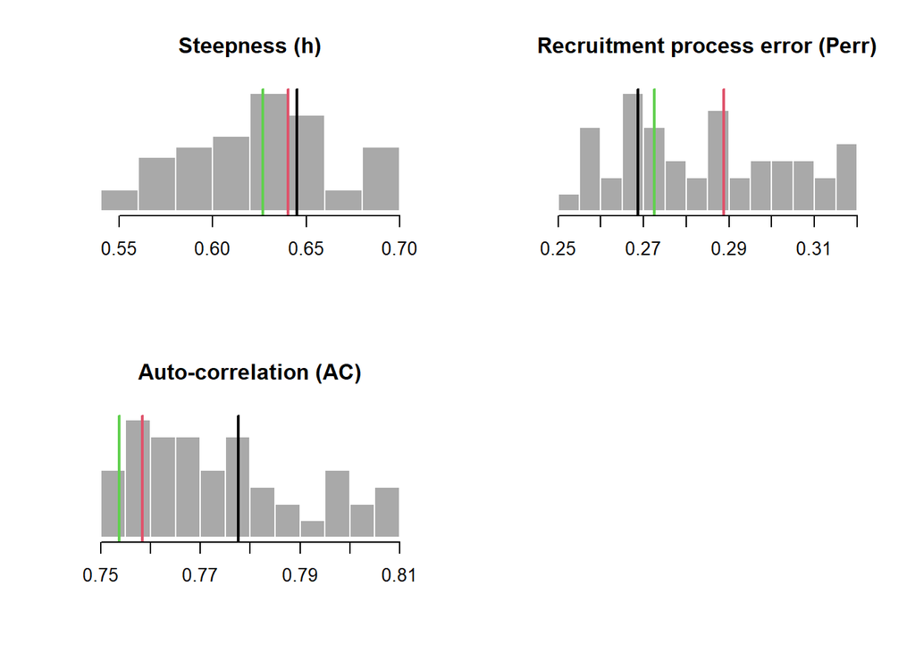

#### Time-Series

Time-series plot showing 3 samples of recruitment deviations for historical and projection years:

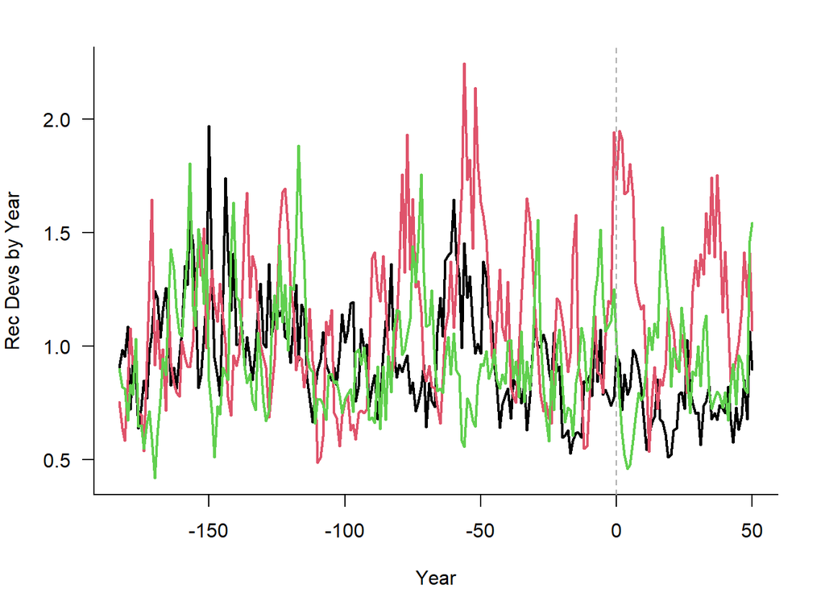

### Growth: Linf, K, t0, LenCV, Ksd, Linfsd

**Linf**: The von Bertalanffy growth parameter Linf, which specifies the average maximum size that would reached by adult fish if they lived indefinitely. For each simulation a single value is drawn from a uniform distribution specified by the upper and lower bounds provided. This value is the same in all years unless Linfsd is a positive number. Uniform distribution lower and upper bounds. Positive real numbers.

Specified in cpars: 55.553, 58.292

The value for females is taken from Table 3, page 9 of the assessment: 56.9cm. Arbitrarily, a small degree of uncertainty is used to bracket this value, +/- 2.5%: 55.5 – 58.3.

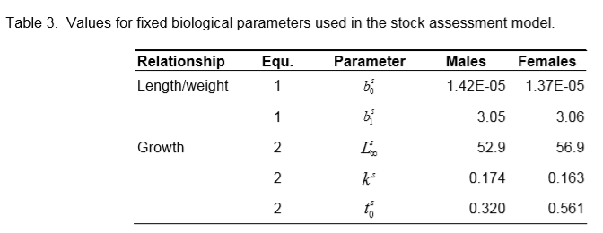

**K**: The von Bertalanffy growth parameter k, which specifies the average rate of growth. For each simulation a single value is drawn from a uniform distribution specified by the upper and lower bounds provided. This value is the same in all years unless Ksd is a positive number. Uniform distribution lower and upper bounds. Positive real numbers.

Specified in cpars: 0.042, 0.228

**t0**: The von Bertalanffy growth parameter t0, which specifies the theoretical age at a size 0. For each simulation a single value is drawn from a uniform distribution specified by the upper and lower bounds provided. Uniform distribution lower and upper bounds. Non-positive real numbers.

Specified Value(s): -0.56, -0.56

Theoretical age at length zero. The value for females is taken exactly and no uncertainty is simulated.

**LenCV**: The coefficient of variation (defined as the standard deviation divided by mean) of the length-at-age. For each simulation a single value is drawn from a uniform distribution specified by the upper and lower bounds provided to specify the distribution of observed length-at-age, and the CV of this distribution is constant for all age classes (i.e, standard deviation increases proportionally with the mean). Uniform distribution lower and upper bounds. Positive real numbers.

Specified Value(s): 0.1, 0.15

Arbitrarily assigned a CV in length at age of between 10 and 15 per cent.

**Ksd**: Inter-annual variation in K. For each simulation a single value is drawn from a uniform distribution specified by the upper and lower bounds provided. If this parameter has a positive value, yearly K is drawn from a log-normal distribution with a mean specified by the value of K drawn for that simulation and a standard deviation (in log space) specified by the value of Ksd drawn for that simulation. Uniform distribution lower and upper bounds. Non-negative real numbers.

Specified Value(s): 0.2, 0.3

Studies of temporal variability in growth of rockfish are not common but older studies of rockfish growth have found moderate inter-annual variability in K values among years with a CV of around 25% (e.g. widow rockfish, Pearson and Hightower 1991).

**Linfsd**: Inter-annual variation in Linf. For each simulation a single value is drawn from a uniform distribution specified by the upper and lower bounds provided. If this parameter has a positive value, yearly Linf is drawn from a log-normal distribution with a mean specified by the value of Linf drawn for that simulation and a standard deviation (in log space) specified by the value of Linfsd drawn for that simulation. Uniform distribution lower and upper bounds. Non-negative real numbers.

Specified Value(s): 0.05, 0.1

Taken from the same study above, this is relatively constant.

### Growth Parameters

#### Sampled Parameters

Histograms of simulations of von Bertalanffy growth parameters `Linf`, `K`, and `t0`, and inter-annual variability in Linf and K (`Linfsd` and `Ksd`), with vertical colored lines indicating 3 randomly drawn values used in other plots:

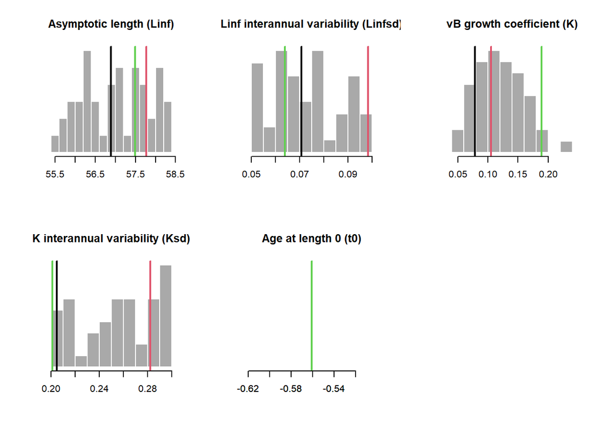

#### Time-Series

The Linf and K parameters in each year for 3 simulations. The vertical dashed line indicates the end of the historical period:

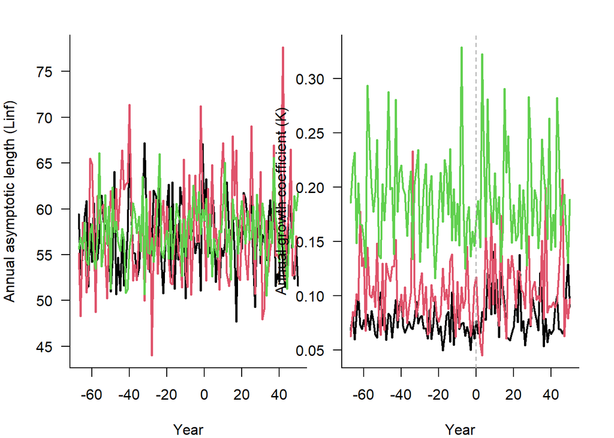

#### Growth Curves

Sampled length-at-age curves for 3 simulations in the first historical year, the last historical year, and the last projection year.

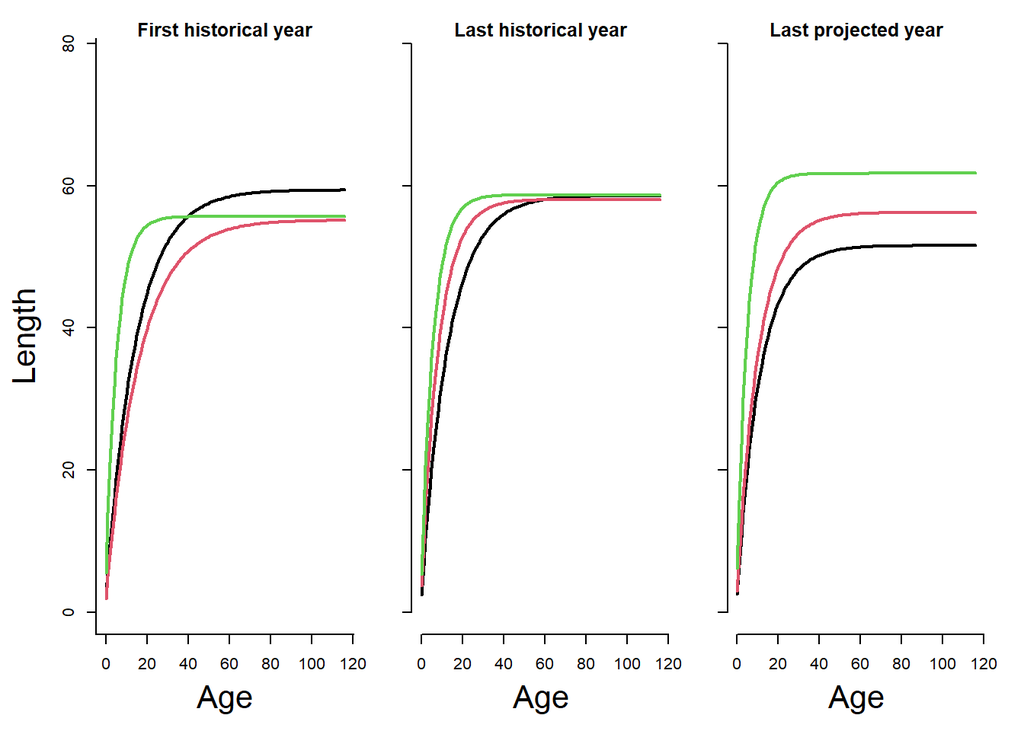

### Maturity: L50, L50_95

**L50**: Length at 50% maturity. For each simulation a single value is drawn from a uniform distribution specified by the upper and lower bounds provided. The L50 and L50_95 parameters are converted to ages using the growth parameters provided and used to construct a logistic curve to determine the proportion of the population that is mature in each age class. Uniform distribution lower and upper bounds. Positive real numbers.

Specified in cpars: 28.771, 55.116

The assessment specifies 50% maturity at age 14. Using the lower bound on K and Linf, the growth curve predicts a length of 48.38 cm= 55.5(1-e-0.1467 x 14). Using the upper bound on K and Linf, the growth curve predicts a length of 53.56 cm = 58.3(1-e-0.1793 x 14). This is quite a naïve basis for guessing length at maturity since it does not account for aging error (compresses uncertainty) but then exaggerates uncertainty by using lower and upper bound pairs of the K and Linf growth parameters that are typically negatively correlated.

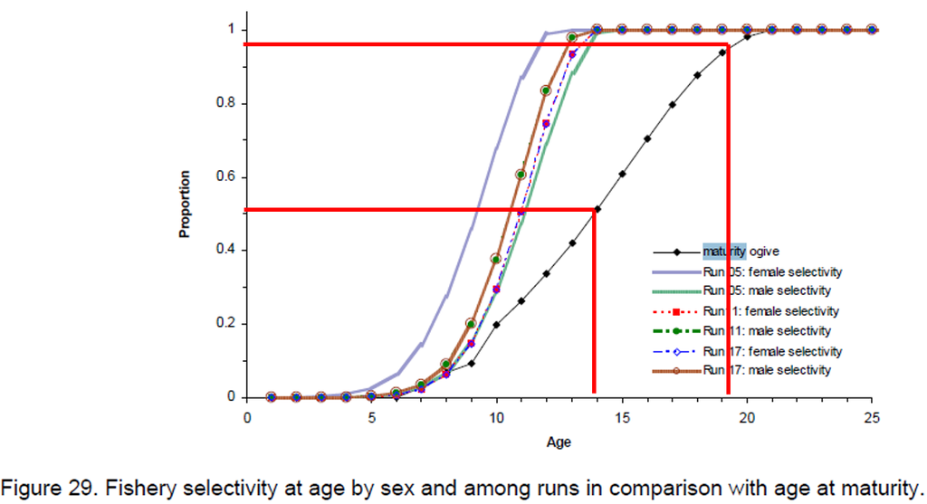

**L50_95**: Difference in lengths between 50% and 95% maturity. For each simulation a single value is drawn from a uniform distribution specified by the upper and lower bounds provided. The value drawn is then added to the length at 50% maturity to determine the length at 95% maturity. This parameterization is used instead of specifying the size at 95 percent maturity to avoid situations where the value drawn for the size at 95% maturity is smaller than that at 50% maturity. The L50 and L50_95 parameters are converted to ages using the growth parameters provided and used to construct a logistic curve to determine the proportion of the population that is mature in each age class. Uniform distribution lower and upper bounds. Positive real numbers.

Specified Value(s): 2, 3

### Maturity Parameters

#### Sampled Parameters

Histograms of simulations of `L50` (length at 50% maturity), and `L95` (length at 95% maturity), with vertical colored lines indicating 3 randomly drawn values used in other plots:

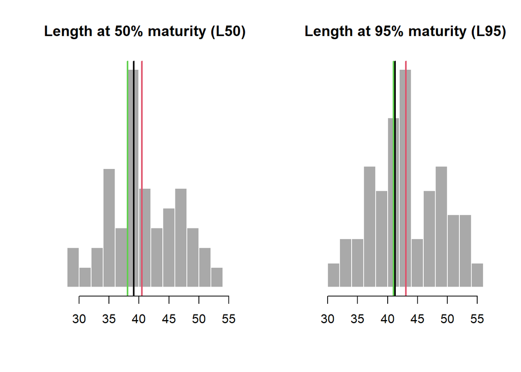

#### Maturity at Age and Length

Maturity-at-age and -length for 3 simulations in the first historical year, the last historical year (i.e., current year), and the last projected year:

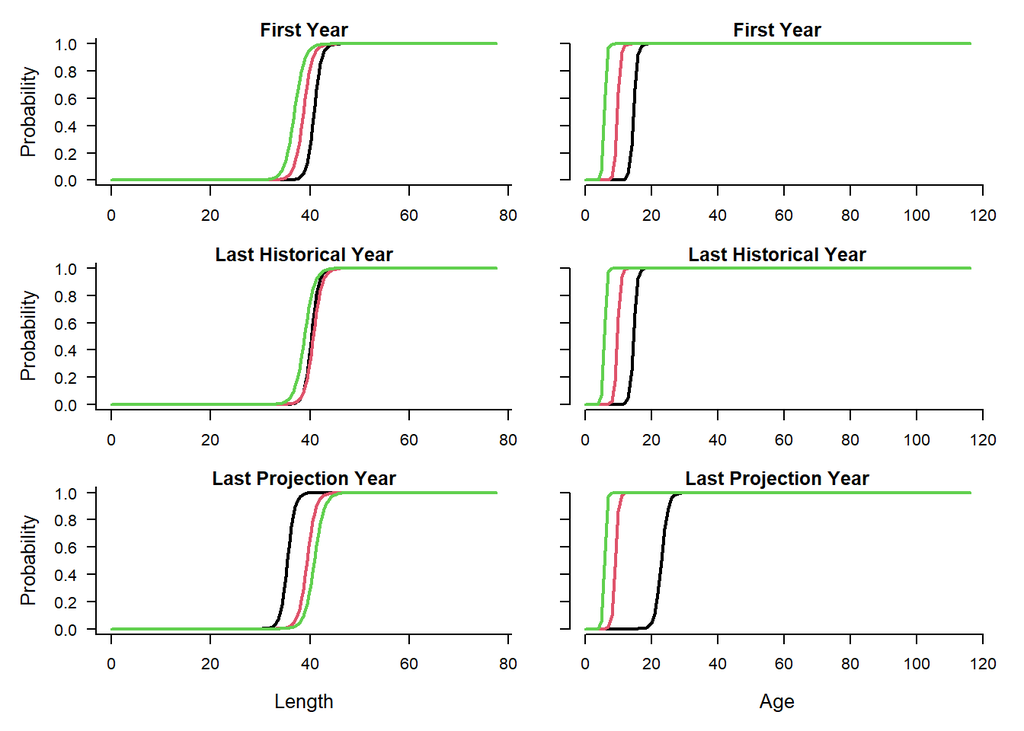

### Stock depletion and Discard Mortality: D, Fdisc

**D**: Estimated current level of stock depletion, which is defined as the current spawning stock biomass divided by the unfished spawning stock biomass. For each simulation a single value is drawn from a uniform distribution specified by the upper and lower bounds provided. This parameter is used during model initialization to select a series of yearly historical recruitment values and fishing mortality rates that, based on the information provided, could have resulted in the specified depletion level in the simulated last historical year. Uniform distribution lower and upper bounds. Positive real numbers (typically < 1)

Specified in cpars: 0.067, 0.198

Since we have a stock assessment with multiple model runs it is relatively straightforward to bracket uncertainty. Table J.10 of page 159 of the assessment provides posterior mean estimates for all models.

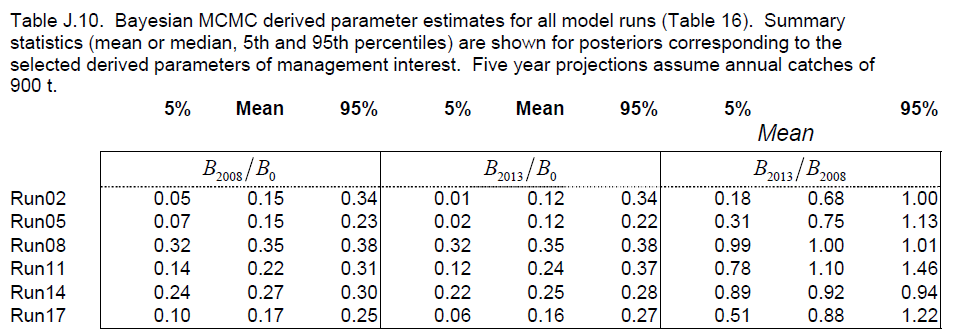

**Fdisc**: The instantaneous discard mortality rate the stock experiences when fished using the gear type specified in the corresponding fleet object and discarded. For each simulation a single value is drawn from a uniform distribution specified by the upper and lower bounds provided. Uniform distribution lower and upper bounds. Non-negative real numbers.

Specified Value(s): 0.8, 1

Discard mortality rate was set to a conservative range of 80 per cent to 100 percent, consistent with the values published by the [Pacific Management Council](http://www.pcouncil.org/wp-content/uploads/D5b_GMT_APR2013BB.pdf)

### Depletion and Discard Mortality

#### Sampled Parameters

Histograms of simulations of depletion (spawning biomass in the last historical year over average unfished spawning biomass; `D`) and the fraction of discarded fish that are killed by fishing mortality (`Fdisc`), with vertical colored lines indicating 3 randomly drawn values.

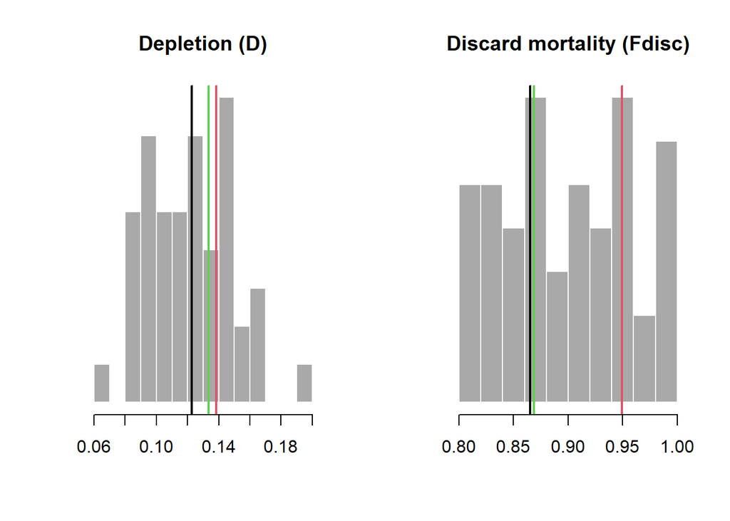

### Length-weight conversion parameters: a, b

**a**: The alpha parameter in allometric length-weight relationship. Single value. Weight parameters are used to determine catch-at-age and population-at-age from the number of individuals in each age class and the length of each individual, which is drawn from a normal distribution determined by the Linf , K , t0 , and LenCV parameters. As a result, they function as a way to scale between numbers at age and biomass, and are not stochastic parameters. Single value. Positive real number.

Specified Value(s): 0

From the assessment document

**b**: The beta parameter in allometric length-weight relationship. Single value. Weight parameters are used to determine catch-at-age and population-at-age from the number of individuals in each age class and the length of each individual, which is drawn from a normal distribution determine by the Linf , K , t0 , and LenCV parameters. As a result, they function as a way to scale between numbers at age and biomass, and are not stochastic parameters. Single value. Positive real number.

Specified Value(s): 3.06

From the assessment document

### Spatial distribution and movement: Size_area_1, Frac_area_1, Prob_staying

**Size_area_1**: The size of area 1 relative to area 2. The fraction of the unfished biomass in area 1. Please specify numbers between 0 and 1. For each simulation a single value is drawn from a uniform distribution specified by the upper and lower bounds provided. For example, if Size_area_1 is 0.2, then 20% of the total area is allocated to area 1. Fishing can occur in both areas, or can be turned off in one area to simulate the effects of a no take marine reserve. Uniform distribution lower and upper bounds. Positive real numbers.

Specified Value(s): 0.1, 0.1

Population is uniformly distributed: size area 1 is same as frac area 1.

**Frac_area_1**: The fraction of the unfished biomass in area 1. Please specify numbers between 0 and 1. For each simulation a single value is drawn from a uniform distribution specified by the upper and lower bounds provided. For example, if Frac_area_1 is 0.5, then 50% of the unfished biomass is allocated to area 1, regardless of the size of area 1 (i.e, size and fraction in each area determine the density of fish, which may impact fishing spatial targeting). In each time step recruits are allocated to each area based on the proportion specified in Frac_area_1. Uniform distribution lower and upper bounds. Positive real numbers.

Specified Value(s): 0.1, 0.1

Frac_area_1 is the default area for testing marine reserves or simulating habitat that is outside of the range of fishing. To simulate a mixed stock we simulate a stock in which 10% of individuals are in area 1 and 90% are in area 2, 0.1.

**Prob_staying**: The probability of individuals in area 1 remaining in area 1 over the course of one year. Please specify numbers between 0 and 1. For each simulation a single value is drawn from a uniform distribution specified by the upper and lower bounds provided. For example, in an area with a Prob_staying value of 0.95 each fish has a 95% probability of staying in that area in each time step, and a 5% probability of moving to the other area. Uniform distribution lower and upper bounds. Positive fraction.

Specified Value(s): 0.85, 0.95

To simulate uncertain mixing among areas I assume that between 85 per cent and 95 per cent of individuals remain in the same area among years.

### Spatial & Movement

#### Sampled Parameters

Histograms of 48 simulations of size of area 1 (`Size_area_1`), fraction of unfished biomass in area 1 (`Frac_area_1`), and the probability of staying in area 1 in a year (`Frac_area_1`), with vertical colored lines indicating 3 randomly drawn values used in other plots:

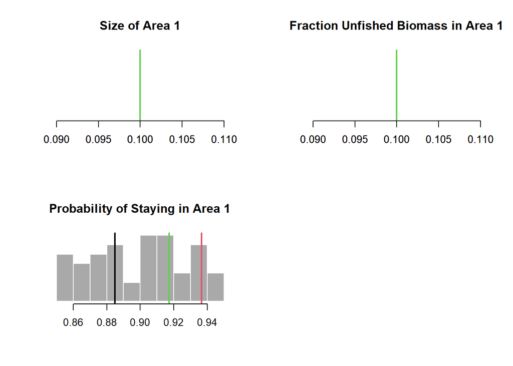

# Fleet Parameters

### Historical years of fishing, spatial targeting: nyears, Spat_targ

**nyears**: The number of years for the historical simulation. Single value. For example, if the simulated population is assumed to be unfished in 1975 and this is the year you want to start your historical simulations, and the most recent year for which there is data available is 2019, then nyears equals 45.

Specified Value(s): 68

The data from the assessment run from 1940-2007, a total of 68 years.

**Spat_targ**: Distribution of fishing in relation to vulnerable biomass (VB) across areas. The distribution of fishing effort is proportional to VB^Spat_targ. Upper and lower bounds of a uniform distribution. For each simulation a single value is drawn from a uniform distribution specified by the upper and lower bounds provided. This parameter allows the user to model either avoidance or spatial targeting behavior by the fleet. If the parameter value is 1, fishing effort is allocated across areas in proportion to the population density of that area. Values below 1 simulate an avoidance behavior and values above 1 simulate a targeting behavior.

Specified Value(s): 1, 1

Spatial targetting. We’re going to stick to the default level of 1 (effort distributed in proportion to density)

### Trend in historical fishing effort (exploitation rate), interannual variability in fishing effort: EffYears, EffLower, EffUpper, Esd

**EffYears**: Vector indicating the historical years where there is information available to infer the relative fishing effort expended.This vector is specified in terms of the position of the year in the vector rather than the calendar year. For example, say our simulation starts with an unfished stock in 1975,and the current year (the last year for which there is data available) is 2019. Then there are 45 historical years simulated, and EffYears should include numbers between 1 and 45. Note that there may not be information available for every historical year, especially for data poor fisheries. In these situations, the EffYears vector should include only the positions of the years for which there is information, and the vector may be shorter than the total number of simulated historical years (nyears).

Specifying historical pattern of exploitation rate (relative fishing mortality rate (sometimes assumed to be proportional to fishing effort) is easy in this case as we have the stock assessment prediction of exploitation rate (Figure J.5, page 172). I used WebPlotDigitizer (http://arohatgi.info/WebPlotDigitizer/app/) to rip these data. Table J.9 on page 159 shows considerable uncertainty in exploitation rates with a mean range of +/- 40% for harvest rate in 2007, bounds that used here to bracket the trend extracted from Table J.5.

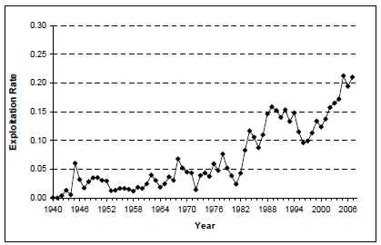

Figure J.5 of the assessment report

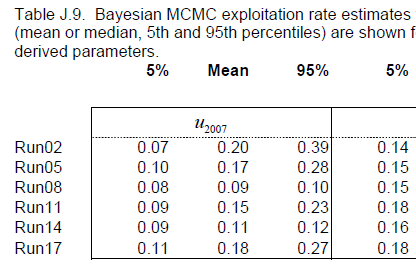

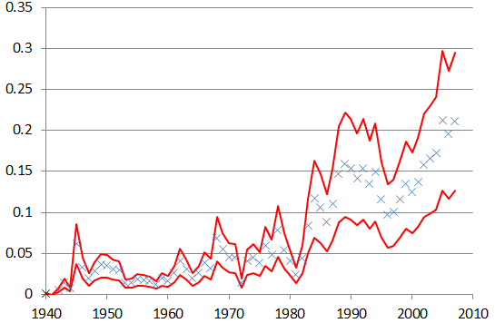

**EffLower**: Lower bound on relative fishing effort corresponding to EffYears. EffLower must be a vector that is the same length as EffYears describing how fishing effort has changed over time. Information on relative fishing effort can be entered in any units provided they are consistent across the entire vector because the data provided will be scaled to 1 (divided by the maximum number provided).

From the SSRA.

**EffUpper**: Upper bound on relative fishing effort corresponding to EffYears. EffUpper must be a vector that is the same length as EffYears describing how fishing effort has changed over time. Information on relative fishing effort can be entered in any units provided they are consistent across the entire vector because the data provided will be scaled to 1 (divided by the maximum number provided).

From the SSRA.

| EffYears | EffLower | EffUpper |
| --- | --- | --- |
| 1941 | 0.01 | 0.02 |
| 1942 | 0.01 | 0.02 |
| 1943 | 0.04 | 0.10 |
| 1944 | 0.12 | 0.28 |
| 1945 | 0.05 | 0.13 |
| 1946 | 0.52 | 1.22 |
| 1947 | 0.27 | 0.64 |
| 1948 | 0.16 | 0.37 |
| 1949 | 0.24 | 0.56 |
| 1950 | 0.30 | 0.70 |
| 1951 | 0.29 | 0.68 |
| 1952 | 0.26 | 0.61 |
| 1953 | 0.25 | 0.58 |
| 1954 | 0.11 | 0.26 |
| 1955 | 0.12 | 0.28 |
| 1956 | 0.15 | 0.35 |
| 1957 | 0.14 | 0.34 |
| 1958 | 0.13 | 0.31 |
| 1959 | 0.10 | 0.23 |
| 1960 | 0.16 | 0.37 |
| 1961 | 0.14 | 0.32 |
| 1962 | 0.21 | 0.50 |
| 1963 | 0.34 | 0.80 |
| 1964 | 0.26 | 0.61 |
| 1965 | 0.16 | 0.37 |
| 1966 | 0.21 | 0.50 |
| 1967 | 0.32 | 0.74 |
| 1968 | 0.27 | 0.62 |
| 1969 | 0.57 | 1.34 |
| 1970 | 0.46 | 1.07 |
| 1971 | 0.38 | 0.89 |
| 1972 | 0.38 | 0.88 |
| 1973 | 0.12 | 0.28 |
| 1974 | 0.34 | 0.79 |
| 1975 | 0.38 | 0.88 |
| 1976 | 0.32 | 0.74 |
| 1977 | 0.50 | 1.18 |
| 1978 | 0.41 | 0.95 |
| 1979 | 0.66 | 1.54 |
| 1980 | 0.45 | 1.06 |
| 1981 | 0.34 | 0.79 |
| 1982 | 0.20 | 0.47 |
| 1983 | 0.37 | 0.86 |
| 1984 | 0.71 | 1.66 |
| 1985 | 0.99 | 2.32 |
| 1986 | 0.90 | 2.09 |
| 1987 | 0.75 | 1.75 |
| 1988 | 0.93 | 2.18 |
| 1989 | 1.25 | 2.92 |
| 1990 | 1.35 | 3.16 |
| 1991 | 1.31 | 3.05 |
| 1992 | 1.20 | 2.80 |
| 1993 | 1.31 | 3.05 |
| 1994 | 1.15 | 2.68 |
| 1995 | 1.27 | 2.96 |
| 1996 | 0.98 | 2.29 |
| 1997 | 0.82 | 1.91 |
| 1998 | 0.85 | 1.99 |
| 1999 | 0.99 | 2.30 |
| 2000 | 1.14 | 2.66 |
| 2001 | 1.06 | 2.47 |
| 2002 | 1.17 | 2.72 |
| 2003 | 1.35 | 3.14 |
| 2004 | 1.40 | 3.28 |
| 2005 | 1.47 | 3.43 |
| 2006 | 1.81 | 4.22 |
| 2007 | 1.66 | 3.88 |
| 2008 | 1.80 | 4.19 |

**Esd**: Additional inter-annual variability in fishing mortality rate. For each historical simulation a single value is drawn from a uniform distribution specified by the upper and lower bounds provided. If this parameter has a positive (non-zero) value, the yearly fishing mortality rate is drawn from a log-normal distribution with a standard deviation (in log space) specified by the value of Esd drawn for that simulation. This parameter applies only to historical projections.

Specified Value(s): 0, 0

This is really variability in addition to the underlying trend described by EffLower and EffUpper. It is used only to generate historical fishing patterns. In data-limited cases a very simple (general, mean) historical trajectory in effort may be established and it may be desirable to add additional interannual variability to reflect changes in fishing intensity among years. In this case we’re going to be using stock assessment outputs directly that have detailed annual variability information and have no need to superimpose greater variability. It is set to 0.